# Leapfrog Episiotomy rates, 2016-2q2019

By **Christian McDonald**, Assistant Professor of Practice  
School of Journalism, Moody College of Communication  
University of Texas at Austin

This analysis looks at episiotomy rates using the [Texas Health Care Information Collection’s Texas Inpatient Public Use Data File](https://www.dshs.texas.gov/thcic/hospitals/Inpatientpudf.shtm). The definition to calculate the rates comes from the [2019 Leapfrog Hospital Survey p103](https://www.leapfroggroup.org/sites/default/files/Files/2019HospitalSurvey_20190529_v8.0%20%28version%203%29.pdf).

> To start this analysis, I’ve start with data filtered using the 2019 Leapfrog Hospital Survey specs for Episiotomy (p103). The process was done in “01-process-lf-epi-loop”.

## Setup and import

```r
library(tidyverse)
library(janitor)
library(DT)
library(data.table)
```

```r
test_flag <- F

### test data
path_test <- "data-test/lf_del_vag_loop_test.rds"

### production data
path_prod <- "data-processed/lf_del_vag.rds"

### import based on flag
if (test_flag == T) del_vag_excl <- read_rds(path_test) else del_vag_excl <- read_rds(path_prod)

del_vag_excl %>% nrow()
```

```
## [1] 812182
```

### Set the episiotomy cases

This creates a column for cases where episiotomy is true. We have to look through each of the surgical procedure columns to check for the code.

> I’d like to refactor this method, but at least it is easy to see and understand.

```r
# list of codes for episiotmy, which is really one: 0W8NXZZ
epi_list <- read_rds("procedures-lists/lf_epi.rds") %>% .$epi
epi_list
```

```
## [1] "0W8NXZZ"
```

```r
del_epi <- del_vag_excl %>%
  mutate(
    EPI = case_when(
      PRINC_SURG_PROC_CODE %in% epi_list ~ TRUE,
      OTH_SURG_PROC_CODE_1 %in% epi_list ~ TRUE,
      OTH_SURG_PROC_CODE_2 %in% epi_list ~ TRUE,
      OTH_SURG_PROC_CODE_3 %in% epi_list ~ TRUE,
      OTH_SURG_PROC_CODE_4 %in% epi_list ~ TRUE,
      OTH_SURG_PROC_CODE_5 %in% epi_list ~ TRUE,
      OTH_SURG_PROC_CODE_6 %in% epi_list ~ TRUE,
      OTH_SURG_PROC_CODE_7 %in% epi_list ~ TRUE,
      OTH_SURG_PROC_CODE_8 %in% epi_list ~ TRUE,
      OTH_SURG_PROC_CODE_9 %in% epi_list ~ TRUE,
      OTH_SURG_PROC_CODE_10 %in% epi_list ~ TRUE,
      OTH_SURG_PROC_CODE_11 %in% epi_list ~ TRUE,
      OTH_SURG_PROC_CODE_12 %in% epi_list ~ TRUE,
      OTH_SURG_PROC_CODE_13 %in% epi_list ~ TRUE,
      OTH_SURG_PROC_CODE_14 %in% epi_list ~ TRUE,
      OTH_SURG_PROC_CODE_15 %in% epi_list ~ TRUE,
      OTH_SURG_PROC_CODE_16 %in% epi_list ~ TRUE,
      OTH_SURG_PROC_CODE_17 %in% epi_list ~ TRUE,
      OTH_SURG_PROC_CODE_18 %in% epi_list ~ TRUE,
      OTH_SURG_PROC_CODE_19 %in% epi_list ~ TRUE,
      OTH_SURG_PROC_CODE_20 %in% epi_list ~ TRUE,
      OTH_SURG_PROC_CODE_21 %in% epi_list ~ TRUE,
      OTH_SURG_PROC_CODE_22 %in% epi_list ~ TRUE,
      OTH_SURG_PROC_CODE_23 %in% epi_list ~ TRUE,
      OTH_SURG_PROC_CODE_24 %in% epi_list ~ TRUE,
      TRUE ~ FALSE
    )
  )
```

## Statewide episiotomy rate, 2016-2q2019

We combine all years of data to compare the percentage of episiotomy cases. The **TRUE** value is the percentage of cases where an episiotomy is performed.

```r
del_epi %>%
  tabyl(EPI) %>%
  rename(count = n) %>%
  adorn_pct_formatting()
```

| EPI | count | percent |
| --- | --- | --- |
| FALSE | 746050 | 91.9% |
| TRUE | 66132 | 8.1% |

## Searchable table: Episiotomy rates by hospital, combined years

Hospitals with fewer than 100 deliveries excluded.

```r
del_epi_data <- del_epi %>%
  group_by(PROVIDER_NAME, EPI) %>%
  summarise(
    EPI_CNT = n()
  ) %>%
  pivot_wider(names_from = EPI, values_from = EPI_CNT) %>%
  rename(
    EPIF = "FALSE",
    EPIT = "TRUE"
  ) %>%
  mutate(
    TOTAL = EPIF + EPIT,
    EPIRATE = round((EPIT / TOTAL) * 100,1)
  ) %>%
  select(PROVIDER_NAME, TOTAL, EPIF, EPIT, EPIRATE) %>%
  filter(TOTAL >= 100) %>%
  arrange(EPIRATE %>% desc())

del_epi_data %>%
    datatable()
```

|  | PROVIDER_NAME | TOTAL | EPIF | EPIT | EPIRATE |
| --- | --- | --- | --- | --- | --- |
| 1 | Baylor Scott &amp; White Medical Center Sunnyvale | 379 | 250 | 129 | 34 |
| 2 | Matagorda Regional Medical Center | 1235 | 900 | 335 | 27.1 |
| 3 | Hopkins County Memorial Hospital | 216 | 158 | 58 | 26.9 |
| 4 | Mission Regional Medical Center | 3386 | 2480 | 906 | 26.8 |
| 5 | Dallas Regional Medical Center | 1367 | 1005 | 362 | 26.5 |
| 6 | Val Verde Regional Medical Center | 1731 | 1308 | 423 | 24.4 |
| 7 | Christus Mother Frances Hospital Sulphur Springs | 1136 | 868 | 268 | 23.6 |
| 8 | Covenant Medical Center-Lakeside | 1476 | 1133 | 343 | 23.2 |
| 9 | Odessa Regional Medical Center | 5090 | 3938 | 1152 | 22.6 |
| 10 | Valley Regional Medical Center | 3388 | 2624 | 764 | 22.6 |

[output cut: 266 more lines]

### Mean, Median of episiotomy rates by hospital

The mean/median taken from the episiotomy rate of each hospital.

```r
del_epi_data %>%
  ungroup() %>%
  summarise(
    MEAN = round(mean(EPIRATE, na.rm=TRUE),2),
    MEDIAN = median(EPIRATE, na.rm=TRUE)
  )
```

| MEAN | MEDIAN |
| --- | --- |
| 8.5 | 7 |

### Episiotomy rates by hospital, by year

A look at the episiotomy rates for hospitals by year. We create the rate using the EPI column we created above, then pivot to do the math. We pivot again to see the years nicely in a table.

```r
# pivot to crate the rate based on logical EPI column
del_epi_yr_data <- del_epi %>%
  group_by(YR, PROVIDER_NAME, EPI) %>%
  summarise(
    EPI_CNT = n()
  ) %>%
  pivot_wider(names_from = EPI, values_from = EPI_CNT) %>%
  rename(
    EPIF = "FALSE",
    EPIT = "TRUE"
  ) %>%
  mutate(
    TOTAL = EPIF + EPIT,
    EPIRATE = round((EPIT / TOTAL) * 100,1)
  )

# select, pivot to see years.
del_epi_yr_table <- del_epi_yr_data %>%
  filter(TOTAL >= 100) %>%
  select(YR, PROVIDER_NAME, EPIRATE) %>%
  pivot_wider(names_from = YR, values_from = EPIRATE) %>%
  arrange(`2019` %>% desc())

del_epi_yr_table %>% datatable()
```

|  | PROVIDER_NAME | 2016 | 2017 | 2018 | 2019 |
| --- | --- | --- | --- | --- | --- |
| 1 | Doctors Hospital-Laredo | 18.6 | 18.9 | 26.1 | 28.8 |
| 2 | Val Verde Regional Medical Center | 24.4 | 25.2 | 21.8 | 28.4 |
| 3 | Matagorda Regional Medical Center | 22.2 | 31.1 | 30.2 | 24.2 |
| 4 | CHI St Lukes Health Brazosport |  | 13.8 | 17.5 | 23.9 |
| 5 | Dallas Regional Medical Center | 34.7 | 28.6 | 20.2 | 23.4 |
| 6 | Harlingen Medical Center | 15 | 17.3 | 17.3 | 22.9 |
| 7 | Mission Regional Medical Center | 26 | 33 | 23 | 20.7 |
| 8 | Christus Mother Frances Hospital Sulphur Springs | 22.6 | 21.7 | 27.6 | 19.9 |
| 9 | HCA Houston Healthcare Cypress Fairbanks |  |  |  | 19.8 |
| 10 | Wilson N Jones Regional Medical Center | 16.8 | 21.1 | 23 | 19.6 |

[output cut: 256 more lines]

## Laredo hospitals

Build a Laredo hospital set used for some sets.

```r
del_epi_lar <- del_epi %>%
  filter(str_detect(PROVIDER_NAME, "Laredo"))
```

### Episiotomy rate combined year, Laredo hospitals

From combined years of the data.

```r
# filter for laredo hospitals

del_epi_lar %>%
  tabyl(PROVIDER_NAME, EPI) %>%
  adorn_percentages() %>%
  adorn_pct_formatting() %>%
  adorn_ns()
```

|  | PROVIDER_NAME | FALSE | TRUE |
| --- | --- | --- | --- |
| 1 | Doctors Hospital-Laredo | 78.0% (2397) | 22.0% (678) |
| 2 | Laredo Medical Center | 82.5% (5132) | 17.5% (1088) |

### Episiotomy rates by year, Laredo hospitals

The table above, filtered for Laredo.

```r
# filter for Laredo
del_epi_yr_table %>%
  filter(str_detect(PROVIDER_NAME, "Laredo"))
```

| PROVIDER_NAME | 2016 | 2017 | 2018 | 2019 |
| --- | --- | --- | --- | --- |
| Doctors Hospital-Laredo | 18.6 | 18.9 | 26.1 | 28.8 |
| Laredo Medical Center | 16.7 | 17.7 | 18.3 | 17.1 |

### Chart: Episiotomy rates by year, Laredo

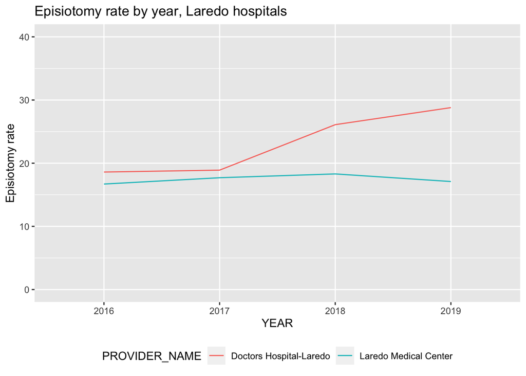

```r
del_epi_yr_data %>%
  filter(str_detect(PROVIDER_NAME, "Laredo")) %>%
  ggplot(aes(YR, EPIRATE)) +
  geom_line(aes(group = PROVIDER_NAME, color = PROVIDER_NAME)) +
  expand_limits(y = c(0,40)) +
  theme(legend.position="bottom", legend.box = "vertical") +
  labs(title = "Episiotomy rate by year, Laredo hospitals", x = "YEAR", y = "Episiotomy rate")
```

### Chart: Episiotomy rates by quarter, Laredo

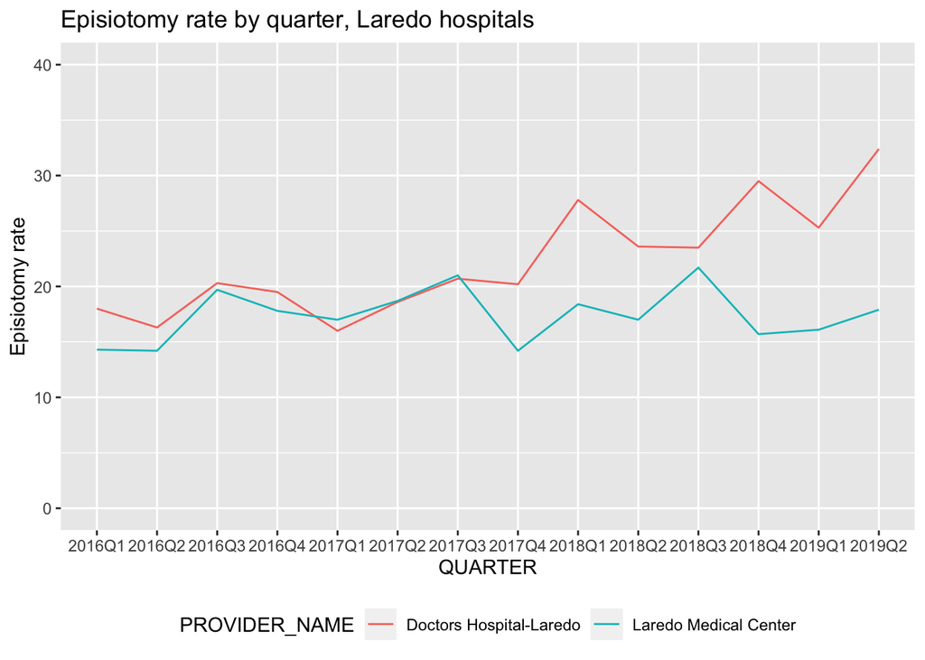

```r
del_epi_qr_data <- del_epi %>%
  group_by(DISCHARGE, PROVIDER_NAME, EPI) %>%
  summarise(
    EPI_CNT = n()
  ) %>%
  pivot_wider(names_from = EPI, values_from = EPI_CNT) %>%
  rename(
    EPIF = "FALSE",
    EPIT = "TRUE"
  ) %>%
  mutate(
    TOTAL = EPIF + EPIT,
    EPIRATE = round((EPIT / TOTAL) * 100,1)
  )

del_epi_qr_data %>%
  filter(str_detect(PROVIDER_NAME, "Laredo")) %>%
  ggplot(aes(DISCHARGE, EPIRATE)) +
  geom_line(aes(group = PROVIDER_NAME, color = PROVIDER_NAME)) +
  expand_limits(y = c(0,40)) +
  theme(legend.position="bottom", legend.box = "vertical") +
  labs(title = "Episiotomy rate by quarter, Laredo hospitals", x = "QUARTER", y = "Episiotomy rate")
```

## A look at doctors

These views are all of vaginal deliveries only. See 02-analysis-deliveries for a look against all deliveries.

Before looking at individual doctor counts, I need to ensure anonymity for them. The challenge is to provide useful information while staying within the allowances of data use.

### Doctor suppression

Before looking at these rates it should be known that in some cases the ATTENDING_PHYSICIAN was suppressed in the data. This means multiple unknown physicians could be grouped as a single doctor in a given quarter. The number of records affected is small, but so is the actual number of physicians at these hospitals.

These suppression rates are just for this data set of **vaginal deliveries in Laredo**.

```r
suppressed = c("9999999998", "9999999999")

del_epi_lar %>%
  mutate(
    DOC_SUPPRESSED = if_else(ATTENDING_PHYSICIAN_UNIF_ID %in% suppressed, T, F)
  ) %>%
  tabyl(DOC_SUPPRESSED, PROVIDER_NAME) %>%
  adorn_percentages("col") %>%
  adorn_pct_formatting(digits = 2) %>%
  adorn_ns()
```

|  | DOC_SUPPRESSED | Doctors Hospital-Laredo | Laredo Medical Center |
| --- | --- | --- | --- |
| 1 | FALSE | 96.98% (2982) | 99.13% (6166) |
| 2 | TRUE | 3.02% (93) | 0.87% (54) |

## Doctors performing vaginal deliveries in Laredo

Includes doctors who IDs were suppresed and therefore combined.

```r
del_epi_lar %>%
  group_by(PROVIDER_NAME) %>%
  summarize(
    DELIVERIES = n(),
    PHYSICIANS = n_distinct(ATTENDING_PHYSICIAN_UNIF_ID)
    ) %>%
  mutate(
    RATE = round(DELIVERIES/PHYSICIANS, 1)
  ) %>%
  arrange(RATE %>% desc())
```

| PROVIDER_NAME | DELIVERIES | PHYSICIANS | RATE |
| --- | --- | --- | --- |
| Laredo Medical Center | 6220 | 21 | 296.2 |
| Doctors Hospital-Laredo | 3075 | 19 | 161.8 |

### Chart: Count of doctors performing vaginal deliveries at each hospital

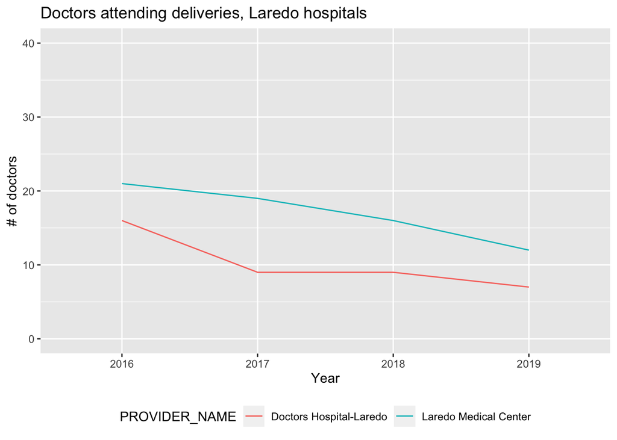

```r
del_epi_lar %>%
  distinct(YR,PROVIDER_NAME, ATTENDING_PHYSICIAN_UNIF_ID) %>%
  count(YR, PROVIDER_NAME) %>%
  rename(
    ATTEND_DOCS = n
    ) %>%
  ggplot(aes(YR, ATTEND_DOCS)) +
  geom_line(aes(group = PROVIDER_NAME, color = PROVIDER_NAME)) +
  expand_limits(y = c(0,40)) +
  theme(legend.position="bottom", legend.box = "vertical") +
  labs(title = "Doctors attending deliveries, Laredo hospitals", x = "Year", y = "# of doctors")
```

### Table: Count of doctors performing vaginal deliveries at each hospital

```r
del_epi_lar %>%
  distinct(YR,PROVIDER_NAME, ATTENDING_PHYSICIAN_UNIF_ID) %>%
  count(YR, PROVIDER_NAME) %>%
  rename(
    ATTEND_DOCS = n
  ) %>%
  pivot_wider(names_from = YR, values_from = ATTEND_DOCS)
```

| PROVIDER_NAME | 2016 | 2017 | 2018 | 2019 |
| --- | --- | --- | --- | --- |
| Doctors Hospital-Laredo | 16 | 9 | 9 | 7 |
| Laredo Medical Center | 21 | 19 | 16 | 12 |

## Write files

Writing out some data frames for use in other notebooks

```r
# del_epi %>% write_rds("data-processed/epi.rds")

beepr::beep(4)
```